# R11546014_ASS01

```python
import pandas as pd
import numpy as np
from pandas import DataFrame
import statsmodels.api as sm
```

```python
# read 'MDS_Assignment1_furnace.csv' file
furnace_df = pd.read_csv('MDS_Assignment1_furnace.csv')
furnace_df
```

|  | f0 | f1 | f2 | f3 | f4 | f5 | f6 | f7 | f8 | f9 | ... | f19 | f20 | f21 | f22 | f23 | f24 | f25 | f26 | f27 | grade |
| --- | --- | --- | --- | --- | --- | --- | --- | --- | --- | --- | --- | --- | --- | --- | --- | --- | --- | --- | --- | --- | --- |
| 0 | 1.848564 | -0.264250 | -0.461423 | 0.409400 | 1.305455 | 2.329398 | 0.370965 | 0.090167 | 0.107958 | 0.0 | ... | 0.085505 | 0.233285 | -1.080663 | 0.443257 | -0.406121 | -0.687687 | 0.271886 | 3.727218 | 0.102129 | 2 |
| 1 | -0.825098 | -0.264250 | 3.032397 | -2.442599 | 1.305455 | -0.276144 | 0.370965 | 0.090167 | 0.107958 | 0.0 | ... | 0.085505 | 0.233285 | -1.080663 | -0.232546 | -0.406366 | -0.687687 | 0.271886 | -0.232472 | 0.102129 | 4 |
| 2 | 1.848564 | -0.264250 | -0.461423 | 0.409400 | 1.305455 | 2.329398 | 0.370965 | 0.090167 | 0.107958 | 0.0 | ... | 0.085505 | 0.233285 | 0.925358 | 1.459782 | 1.221876 | 1.877777 | 0.271886 | -0.232472 | 0.102129 | 2 |
| 3 | 0.511733 | -0.264250 | -0.461423 | 0.409400 | -0.525726 | -0.276144 | 0.370965 | 0.090167 | 0.107958 | 0.0 | ... | 0.085505 | 0.233285 | 0.925358 | -0.008030 | -0.406366 | 1.504523 | 0.271886 | -0.232472 | 0.102129 | 2 |
| 4 | -0.825098 | -0.264250 | -0.461423 | 0.409400 | -0.525726 | -0.276144 | 0.370965 | 0.090167 | 0.107958 | 0.0 | ... | 0.085505 | 0.233285 | 0.925358 | -0.573268 | -1.164793 | 1.877777 | 0.271886 | -0.232472 | 0.102129 | 2 |
| ... | ... | ... | ... | ... | ... | ... | ... | ... | ... | ... | ... | ... | ... | ... | ... | ... | ... | ... | ... | ... | ... |
| 615 | -0.825098 | -0.264250 | 2.004803 | -2.442599 | 1.305455 | -0.276144 | 0.370965 | 0.090167 | 0.107958 | 0.0 | ... | 0.085505 | 0.233285 | -1.080663 | -0.684962 | -0.406121 | -0.687687 | 0.271886 | -0.232472 | 0.102129 | 2 |
| 616 | -0.379487 | 3.809407 | -0.461423 | 0.409400 | 1.305455 | -0.276144 | 0.370965 | 0.090167 | 0.107958 | 0.0 | ... | 0.085505 | 0.233285 | -1.080663 | 2.248407 | -0.332678 | -0.687687 | 0.271886 | 4.519156 | 0.102129 | 2 |
| 617 | -0.825098 | -0.264250 | -0.461423 | 0.409400 | -0.525726 | -0.276144 | 0.370965 | 0.090167 | 0.107958 | 0.0 | ... | 0.085505 | 0.233285 | -1.080663 | -1.023427 | 1.332042 | -0.687687 | 0.271886 | -0.232472 | 0.102129 | 2 |
| 618 | -0.825098 | -0.264250 | 2.004803 | -2.442599 | 1.305455 | -0.276144 | 0.370965 | 0.090167 | 0.107958 | 0.0 | ... | 0.085505 | 0.233285 | -1.080663 | 3.150982 | -1.777067 | -0.687687 | 0.271886 | -0.232472 | 0.102129 | 2 |
| 619 | -0.379487 | 3.068742 | -0.461423 | 0.409400 | 1.305455 | -0.276144 | 0.370965 | 0.090167 | 0.107958 | 0.0 | ... | 0.085505 | 0.233285 | -1.080663 | 1.120188 | 0.303833 | -0.687687 | 0.271886 | -0.232472 | 0.102129 | 2 |

620 rows × 29 columns

#### (a)

```python
train_columns = furnace_df.columns[0:28]
x_train = furnace_df.loc[:, :'f27'] # 將'f0'-'f27'的值存入x_train
y_train = furnace_df['grade'] # 將'grade'的值存入y_train
x_train = sm.add_constant(x_train) #因需考量到數據之偏差，故加入常數變量
```

```python
model = sm.OLS(y_train, x_train).fit() # 使用最小二乘法做回歸分析
OLS_Summary = model.summary()
```

```python
# print('R-square : {0}'.format())
from sklearn.linear_model import LinearRegression

modelLin = LinearRegression() # 建regression模型
modelLin.fit(x_train, y_train) # 對x_train及y_train做回歸分析
print('r-square:{:.3f}'.format(modelLin.score(x_train, y_train)))
print('adjusted r-square:{:.3f}'.format(model.rsquared_adj))
OLS_Summary.tables[0]
```

```
r-square:0.495
adjusted r-square:0.472
```

OLS Regression Results

| Dep. Variable: | grade | R-squared: | 0.495 |
| --- | --- | --- | --- |
| Model: | OLS | Adj. R-squared: | 0.472 |
| Method: | Least Squares | F-statistic: | 21.52 |
| Date: | Fri, 07 Oct 2022 | Prob (F-statistic): | 1.16e-70 |
| Time: | 00:04:22 | Log-Likelihood: | -381.52 |
| No. Observations: | 620 | AIC: | 819.0 |
| Df Residuals: | 592 | BIC: | 943.1 |
| Df Model: | 27 |  |  |
| Covariance Type: | nonrobust |  |  |

```python
# 將使用OLS做回歸分析得出來的結果(OLS_Summary)分為上下兩個部分輸出至螢幕
ols_summary = pd.read_html(OLS_Summary.tables[1].as_html(),
                           header=0,
                           index_col=0)[0]
ols_summary = ols_summary[1:]
col_name=['coef','std err','t','P>|t|']
ols_summary[col_name]
```

|  | coef | std err | t | P>\|t\| |
| --- | --- | --- | --- | --- |
| f0 | -5.500000e-03 | 2.500000e-02 | -0.224 | 0.823 |
| f1 | 4.400000e-02 | 2.800000e-02 | 1.571 | 0.117 |
| f2 | 3.140000e-01 | 3.500000e-02 | 9.028 | 0.000 |
| f3 | 1.860000e-02 | 4.200000e-02 | 0.447 | 0.655 |
| f4 | -3.500000e-03 | 3.800000e-02 | -0.091 | 0.928 |
| f5 | -7.400000e-02 | 3.000000e-02 | -2.483 | 0.013 |
| f6 | -7.100000e-02 | 2.600000e-02 | -2.742 | 0.006 |
| f7 | 2.350000e-02 | 2.800000e-02 | 0.853 | 0.394 |
| f8 | 4.100000e-02 | 1.900000e-02 | 2.170 | 0.030 |
| f9 | 1.293000e-16 | 2.340000e-17 | 5.527 | 0.000 |
| f10 | -4.460000e-02 | 2.100000e-02 | -2.119 | 0.035 |
| f11 | -2.920000e-02 | 2.000000e-02 | -1.438 | 0.151 |
| f12 | -6.000000e-04 | 2.200000e-02 | -0.027 | 0.979 |
| f13 | 3.360000e-02 | 2.400000e-02 | 1.412 | 0.159 |
| f14 | -1.832000e-01 | 2.100000e-02 | -8.898 | 0.000 |
| f15 | -1.061000e-01 | 1.900000e-02 | -5.565 | 0.000 |
| f16 | -3.580000e-02 | 2.000000e-02 | -1.756 | 0.080 |
| f17 | 6.330000e-02 | 1.900000e-02 | 3.409 | 0.001 |
| f18 | -1.904000e-01 | 2.100000e-02 | -9.194 | 0.000 |
| f19 | 2.780000e-02 | 2.600000e-02 | 1.051 | 0.294 |
| f20 | 1.260000e-02 | 2.000000e-02 | 0.644 | 0.520 |
| f21 | -3.570000e-02 | 2.800000e-02 | -1.263 | 0.207 |
| f22 | 7.470000e-02 | 2.100000e-02 | 3.533 | 0.000 |
| f23 | -8.800000e-03 | 2.000000e-02 | -0.442 | 0.659 |
| f24 | 1.930000e-02 | 2.400000e-02 | 0.800 | 0.424 |
| f25 | -6.790000e-02 | 2.000000e-02 | -3.406 | 0.001 |
| f26 | -3.600000e-02 | 2.200000e-02 | -1.625 | 0.105 |
| f27 | -6.200000e-03 | 1.900000e-02 | -0.324 | 0.746 |

#### (b)

由上圖可得p-value(prob(F-statistic))=1.16e-70<0.05，拒絕虛無假設，即此迴歸模型具有顯著性。但此模型調整後之可解釋能力R-square = 0.472<0.5，解釋能力較為不佳，發生此現象之原因為添加許多非必要之變數進來迴歸模型(從上圖可知許多變數p-value>0.05，不具顯著性)

#### (c)

```python
# 以p-value做排序，排列出最重要變數
ols_summary.sort_values(by='P>|t|', inplace=True)
significant_variables = ols_summary[ols_summary['P>|t|'] < 0.01]
indexlst = []
for index in significant_variables.index:
    indexlst.append(index)
print("ranked independent variables : " + str(indexlst))
significant_variables[col_name]
```

```
ranked independent variables : ['f2', 'f18', 'f9', 'f22', 'f14', 'f15', 'f25', 'f17', 'f6']
```

|  | coef | std err | t | P>\|t\| |
| --- | --- | --- | --- | --- |
| f2 | 3.140000e-01 | 3.500000e-02 | 9.028 | 0.000 |
| f18 | -1.904000e-01 | 2.100000e-02 | -9.194 | 0.000 |
| f9 | 1.293000e-16 | 2.340000e-17 | 5.527 | 0.000 |
| f22 | 7.470000e-02 | 2.100000e-02 | 3.533 | 0.000 |
| f14 | -1.832000e-01 | 2.100000e-02 | -8.898 | 0.000 |
| f15 | -1.061000e-01 | 1.900000e-02 | -5.565 | 0.000 |
| f25 | -6.790000e-02 | 2.000000e-02 | -3.406 | 0.001 |
| f17 | 6.330000e-02 | 1.900000e-02 | 3.409 | 0.001 |
| f6 | -7.100000e-02 | 2.600000e-02 | -2.742 | 0.006 |

```python
# 算出檢驗殘差分析所需要的殘差值
predictions = model.predict(x_train)
df_results = pd.DataFrame({'Actual': y_train, 'Prediction': predictions})
df_results['Residuals'] = df_results['Actual'] - df_results['Prediction']
df_results
```

|  | Actual | Prediction | Residuals |
| --- | --- | --- | --- |
| 0 | 2 | 1.495438 | 0.504562 |
| 1 | 4 | 2.839074 | 1.160926 |
| 2 | 2 | 1.677606 | 0.322394 |
| 3 | 2 | 1.822888 | 0.177112 |
| 4 | 2 | 1.805390 | 0.194610 |
| ... | ... | ... | ... |
| 615 | 2 | 2.586052 | -0.586052 |
| 616 | 2 | 1.986135 | 0.013865 |
| 617 | 2 | 1.830611 | 0.169389 |
| 618 | 2 | 2.781153 | -0.781153 |
| 619 | 2 | 2.138202 | -0.138202 |

620 rows × 3 columns

```python
# sns.lmplot(x='Prediction',y='Actual',data=df_results,height=5)
# line_coords = np.arange(df_results.min().min(), df_results.max().max())
# plt.plot(line_coords, line_coords,  # X and y points
#              color='darkorange', linestyle='--')
# plt.title('Actual vs. Predicted')
# plt.show()
```

#### Normality

```
p-value:0.0
拒絕虛無假設，殘值並非正態分佈
```

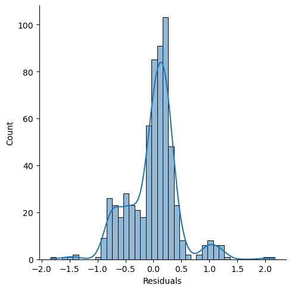

```python
# method 1 使用下列函式庫計算出p-value，由此推論殘差假設為正態分佈是否合適
# H0 : 殘差樣本來自常態分配
# H1 : 殘差樣本非來自常態分配

from statsmodels.stats.diagnostic import normal_ad

p_value = normal_ad(df_results['Residuals'])[1]
print("p-value:{0}".format(p_value))
if p_value < 0.05:
    print("拒絕虛無假設，殘值並非正態分佈")
else:
    print("接受虛無假設，殘值為正態分佈")
sns.displot(df_results['Residuals'], kde=True)
plt.show()
```

```python
# method 2 使用下列函式庫計算出p-value，由此推論殘差假設為正態分佈是否合適
# H0 : 殘差樣本來自常態分配
# H1 : 殘差樣本非來自常態分配
from pingouin import multivariate_normality

multivariate_normality(furnace_df, alpha=0.05)
```

```
HZResults(hz=2480, pval=0.0, normal=False)
```

由上可知p-value=0.0<0.05，拒絕虛無假設，故具有顯著證據表示此次樣本非來自多變量常態分配

#### Homogeneity of Variance

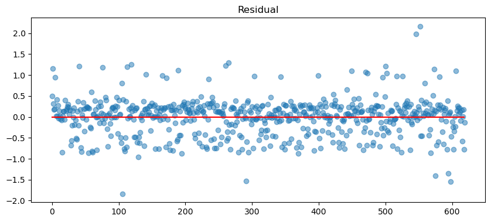

```python
plt.subplots(figsize=(10, 9))
ax = plt.subplot(211)
plt.scatter(x=df_results.index, y=df_results.Residuals, alpha=0.5)
plt.plot(np.repeat(df_results.index.min(), df_results.index.max()),
         linestyle='-',
         color='red')
plt.title('Residual')
```

```python
# bartlett為可檢驗變異數同質性的一種方式
# H0 : 變異數具同質性
# H1 : 變異數不具同質性

import scipy.stats as stats
import scipy.stats as ss
# df_results['Residuals']
gb = furnace_df.groupby('grade')['f0']
statistic, p_value = ss.bartlett(*(gb.get_group(g) for g in gb.groups))
print('P-value:{0}'.format(p_value))
if p_value > 0.05:
    print('變異數同質性成立')
else:
    print('具顯著證據顯示變異數同質性不成立')
```

```
P-value:0.0
具顯著證據顯示變異數同質性不成立
```

### 2. Association Rule- Market Basket Analysis

```python
import pandas as pd
import pandas as pd
```

#### (1)

```python
# read 'MDS_Assignment1_grocery.csv' file
largest_column_count = 0
with open('MDS_Assignment1_groceries.csv', 'r') as groceriesCSV:
    lines = groceriesCSV.readlines()
    for l in lines:
        column_count = len(l.split(',')) + 1
        largest_column_count = column_count if largest_column_count < column_count else largest_column_count
groceriesCSV.close()

column_names = [i for i in range(0, largest_column_count)]

data = pd.read_csv('MDS_Assignment1_groceries.csv',
                   header=None,
                   delimiter=',',
                   names=column_names)
dataArr = []
for i in range(9835):
    dataArr.append(list(data.loc[i].dropna()))
data
```

|  | 0 | 1 | 2 | 3 | 4 | 5 | 6 | 7 | 8 | 9 | ... | 23 | 24 | 25 | 26 | 27 | 28 | 29 | 30 | 31 | 32 |
| --- | --- | --- | --- | --- | --- | --- | --- | --- | --- | --- | --- | --- | --- | --- | --- | --- | --- | --- | --- | --- | --- |
| 0 | citrus fruit | semi-finished bread | margarine | ready soups | NaN | NaN | NaN | NaN | NaN | NaN | ... | NaN | NaN | NaN | NaN | NaN | NaN | NaN | NaN | NaN | NaN |
| 1 | tropical fruit | yogurt | coffee | NaN | NaN | NaN | NaN | NaN | NaN | NaN | ... | NaN | NaN | NaN | NaN | NaN | NaN | NaN | NaN | NaN | NaN |
| 2 | whole milk | NaN | NaN | NaN | NaN | NaN | NaN | NaN | NaN | NaN | ... | NaN | NaN | NaN | NaN | NaN | NaN | NaN | NaN | NaN | NaN |
| 3 | pip fruit | yogurt | cream cheese | meat spreads | NaN | NaN | NaN | NaN | NaN | NaN | ... | NaN | NaN | NaN | NaN | NaN | NaN | NaN | NaN | NaN | NaN |
| 4 | other vegetables | whole milk | condensed milk | long life bakery product | NaN | NaN | NaN | NaN | NaN | NaN | ... | NaN | NaN | NaN | NaN | NaN | NaN | NaN | NaN | NaN | NaN |
| ... | ... | ... | ... | ... | ... | ... | ... | ... | ... | ... | ... | ... | ... | ... | ... | ... | ... | ... | ... | ... | ... |
| 9830 | sausage | chicken | beef | hamburger meat | citrus fruit | grapes | root vegetables | whole milk | butter | whipped/sour cream | ... | NaN | NaN | NaN | NaN | NaN | NaN | NaN | NaN | NaN | NaN |
| 9831 | cooking chocolate | NaN | NaN | NaN | NaN | NaN | NaN | NaN | NaN | NaN | ... | NaN | NaN | NaN | NaN | NaN | NaN | NaN | NaN | NaN | NaN |
| 9832 | chicken | citrus fruit | other vegetables | butter | yogurt | frozen dessert | domestic eggs | rolls/buns | rum | cling film/bags | ... | NaN | NaN | NaN | NaN | NaN | NaN | NaN | NaN | NaN | NaN |
| 9833 | semi-finished bread | bottled water | soda | bottled beer | NaN | NaN | NaN | NaN | NaN | NaN | ... | NaN | NaN | NaN | NaN | NaN | NaN | NaN | NaN | NaN | NaN |
| 9834 | chicken | tropical fruit | other vegetables | vinegar | shopping bags | NaN | NaN | NaN | NaN | NaN | ... | NaN | NaN | NaN | NaN | NaN | NaN | NaN | NaN | NaN | NaN |

9835 rows × 33 columns

#### (2)

```python
# 最上方欄位為商品種類，最左邊之欄位為交易筆數
# 將有購買之物品設為True，未購買之物品設為False

from mlxtend.preprocessing import TransactionEncoder

TstE = TransactionEncoder()
TstE_ary = TstE.fit(dataArr).transform(dataArr)
grocery_df = pd.DataFrame(TstE_ary, columns=te.columns_)

# 使用apriori演算法得到大於最小支持度0.001之購買項目之組合

from mlxtend.frequent_patterns import apriori

items = apriori(grocery_df, min_support=0.001, use_colnames=True)

# 以上面所得到之購買項目可能組合以及其支持度，建立關聯規則
# 並將符合信賴水準>0.15之前五項關聯規則輸出至螢幕

from mlxtend.frequent_patterns import association_rules

rules = association_rules(items, metric="lift", min_threshold=1)
rules = rules[rules['confidence'] > 0.15]
ruleshead = rules[[
    'antecedents', 'consequents', 'support', 'confidence', 'lift'
]].head()
ruleshead
```

|  | antecedents | consequents | support | confidence | lift |
| --- | --- | --- | --- | --- | --- |
| 2 | (Instant food products) | (butter) | 0.001220 | 0.151899 | 2.741145 |
| 7 | (Instant food products) | (curd) | 0.001322 | 0.164557 | 3.088583 |
| 13 | (Instant food products) | (hamburger meat) | 0.003050 | 0.379747 | 11.421438 |
| 17 | (Instant food products) | (other vegetables) | 0.002745 | 0.341772 | 1.766332 |
| 19 | (Instant food products) | (pastry) | 0.001423 | 0.177215 | 1.991899 |

#### (3)

購買方便食品的目的為減少準備食物的時間並且可以以迅速、簡單的形式準備好可以食用的食物，而漢堡肉亦為一種可迅速準備完成的食物，並可提供所需的營養成分，故在購買方便食品時很可能也會一起購買漢堡肉。 從上方的分析圖中可以稍微支持這論點（支持度約0.003、信心水準約37%、提升度約11>1（表示兩種物品成正相關）），但由於信賴水準僅37%<60%（購買方便食品的條件下另外再購買漢堡肉的機率不高），故在做推薦消費者購買其他商品時，推薦列表不該出現漢堡肉此樣商品較為合理

#### (4)

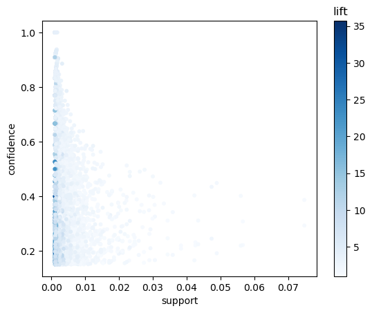

```python
# visualization graph of association rules
# scatter plot

import matplotlib.pyplot as plt

plt.xlabel('support')
plt.ylabel('confidence')
plt.scatter(rules.support, rules.confidence, s=10, c=rules.lift, cmap='Blues')
plt.colorbar().ax.set_title('lift')
plt.show()
```

### 3. Manufacturing System Analysis

#### (a)

```python
# 將題目提供之資料用DataFrame的形式儲存

workspace = {
    "機台數": [3, 3, 6, 2, 5],
    "加工時間(小時)": [5, 8, 12, 4, 12],
    "工作站的產能TH(個/小時)": [0, 0, 0, 0, 0]
}
col_name = ['1', '2', '3', '4', '5']
workspace_pd = pd.DataFrame(workspace, index=col_name)
workspace_pd['機台數'] = workspace_pd['機台數'].astype(float)
workspace_pd['加工時間(小時)'] = workspace_pd['加工時間(小時)'].astype(float)
workspace_pd['工作站的產能TH(個/小時)'] = workspace_pd['工作站的產能TH(個/小時)'].astype(float)
```

```python
# 計算工作站的產能TH

for i in range(len(workspace_pd['機台數'])):
    workspace_pd['工作站的產能TH(個/小時)'][
        i] = workspace_pd['機台數'][i] / workspace_pd['加工時間(小時)'][i]
workspace_pd
```

|  | 機台數 | 加工時間(小時) | 工作站的產能TH(個/小時) |
| --- | --- | --- | --- |
| 1 | 3.0 | 5.0 | 0.600000 |
| 2 | 3.0 | 8.0 | 0.375000 |
| 3 | 6.0 | 12.0 | 0.500000 |
| 4 | 2.0 | 4.0 | 0.500000 |
| 5 | 5.0 | 12.0 | 0.416667 |

而從上表可看出工作站2之產出效率最慢，故工作站2為瓶頸站，其產出率rb=0.375(個/小時)\ 此流水線生產系統之其中一條產線具5個工作站(N=5)，製造完成一樣產品需花費41小時，即最小生產週期時間T0=41(小時)\ 關鍵在製品水準W0=rb*T0=0.375*41=15.375(約略15個)

#### (b)

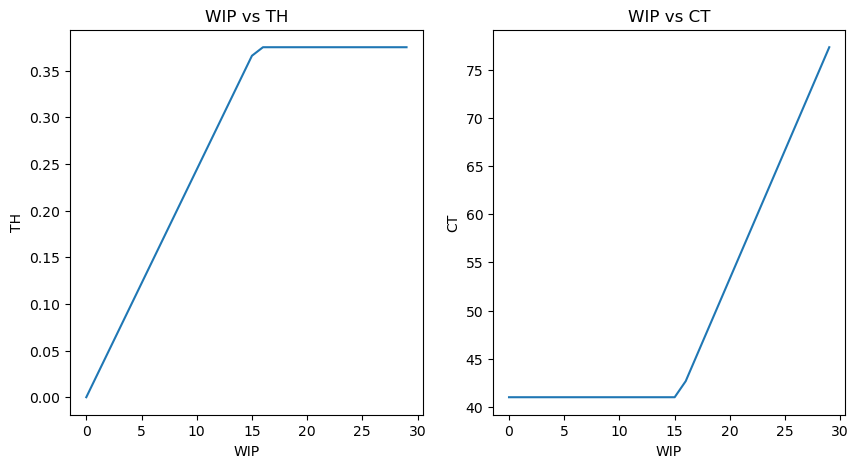

```python
# 參數設定
W0 = 15 # 關鍵在製品水準
T0 = 41 # 最小生產週期時間
rb = 0.375 # 瓶頸站產出率

# 計算CT&TH
ct = []
for wip in range(30):
    if wip <= W0:
        ct.append(T0)
    else:
        ct.append(wip / rb)
th = []
for wip in range(30):
    if wip <= W0:
        th.append(wip / T0)
    else:
        th.append(rb)
fig, (ax1, ax2) = plt.subplots(1, 2,figsize=(10,5))
ax1.plot(list(range(30)), th)
ax1.set_title('WIP vs TH')
ax1.set_xlabel('WIP')
ax1.set_ylabel('TH')

ax2.plot(list(range(30)), ct)
ax2.set_title('WIP vs CT')
ax2.set_xlabel('WIP')
ax2.set_ylabel('CT')
```

產線產出率TH於一開始會緩慢增加，至WIP為W0時，產出率會固定為0.375(個/小時)；而CT在最一開始持平於T0，直到WIP超過W0，開始有產品堆積，壅塞現象逐漸明顯，故CT值會惡化